# Étude de cas - GLM et valeurs manquantes

Romane Lacoste-Badie, Margaux Touzé et Camille Loisel

02/03/2022

Note à nous meme à dégager plus tard : j’ai rajouté le declareunicodecharacter tout en haut sinon ca voulait pas sortir un pdf.

# Modèle linéaire généralisé (GLM) avec R

## Importation des données

```r
#mites<-read.csv("/Users/margauxtouze/Desktop/FAC/M2/S2/Étude de cas/Data/mites.csv")
mites <- read.csv("/Users/romane/Université/Master 2 IS/S4/Étude de cas/data/mites.csv")
str(mites)
```

```
## 'data.frame':    70 obs. of  9 variables:
##  $ Galumna   : int  8 3 1 1 2 1 1 1 2 5 ...
##  $ pa        : int  1 1 1 1 1 1 1 1 1 1 ...
##  $ totalabund: int  140 268 186 286 199 209 162 126 123 166 ...
##  $ prop      : num  0.05714 0.01119 0.00538 0.0035 0.01005 ...
##  $ SubsDens  : num  39.2 55 46.1 48.2 23.6 ...
##  $ WatrCont  : num  350 435 372 360 204 ...
##  $ Substrate : chr  "Sphagn1" "Litter" "Interface" "Sphagn1" ...
##  $ Shrub     : chr  "Few" "Few" "Few" "Few" ...
##  $ Topo      : chr  "Hummock" "Hummock" "Hummock" "Hummock" ...
```

pour LM : chercher à valider les hypothèses, ca marche pas, faire des transformations (Box Cox), réessayer de valider les hyp Si ca marche on dit quon pourrait sarreter la mais on cherche a aller plus loin Si ca marche PAS on cherche un autre modele : GLM (si abundance marche, possibilité de faire +1 pour éviter les valeurs=0)

## 1. LM Gaussien

Tester les hypothèses

# H. 1 Linéarité du modèle

Représentation graphique :

1/ Galumna

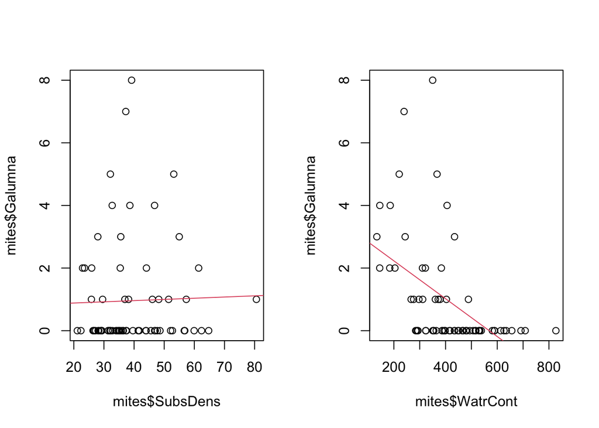

```r
par(mfrow=c(1,2))
lm.g.subsdens<-lm(Galumna~SubsDens, data=mites)
plot(mites$SubsDens, mites$Galumna)
abline(lm.g.subsdens, col=2)
lm.g.watrcont<-lm(Galumna~WatrCont, data=mites)
plot(mites$WatrCont, mites$Galumna)
abline(lm.g.watrcont, col=2)
```

2/ pa

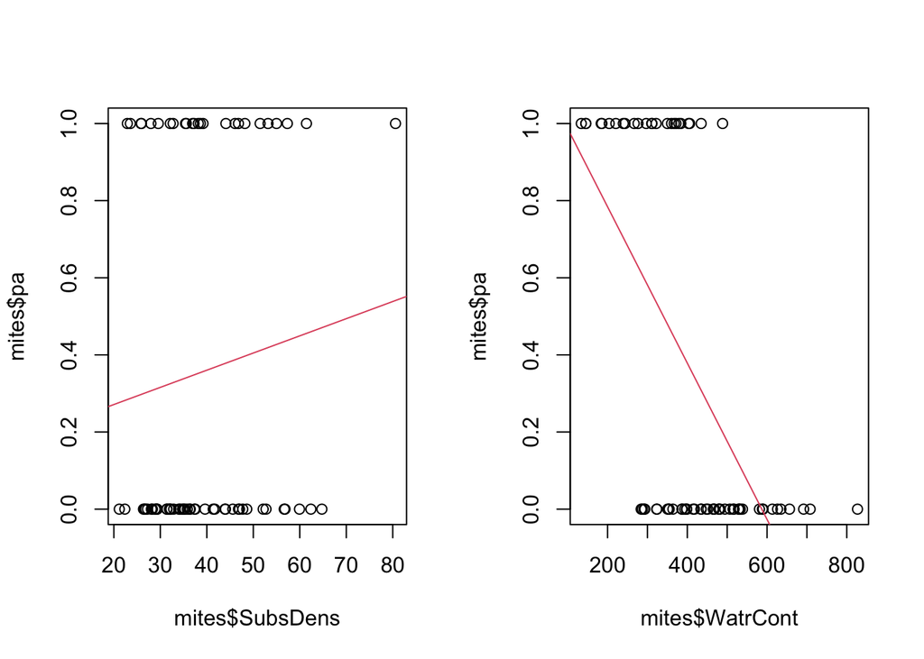

```r
par(mfrow=c(1,2))
lm.pa.subsdens<-lm(pa~SubsDens, data=mites)
plot(mites$SubsDens, mites$pa)
abline(lm.pa.subsdens, col=2)
lm.pa.watrcont<-lm(pa~WatrCont, data=mites)
plot(mites$WatrCont, mites$pa)
abline(lm.pa.watrcont, col=2)
```

3/ prop

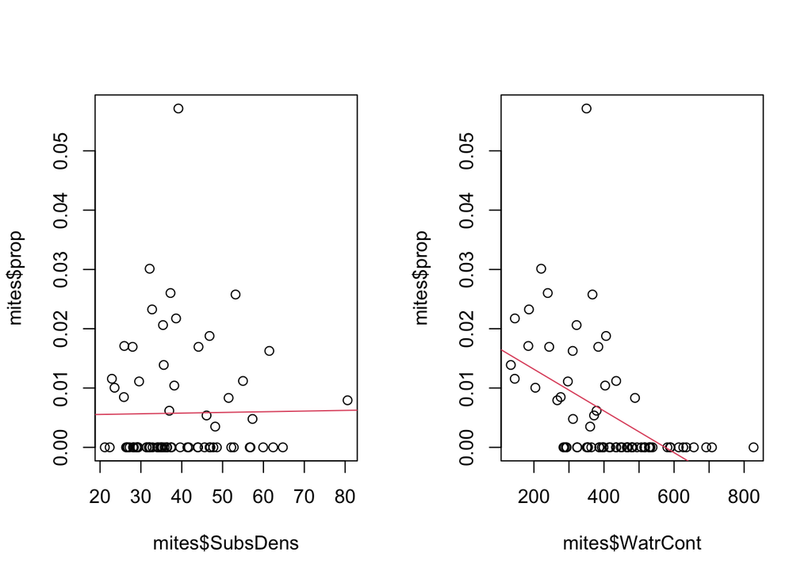

```r
par(mfrow=c(1,2))
lm.prop.subsdens<-lm(prop~SubsDens, data=mites)
plot(mites$SubsDens, mites$prop)
abline(lm.prop.subsdens, col=2)
lm.prop.watrcont<-lm(prop~WatrCont, data=mites)
plot(mites$WatrCont, mites$prop)
abline(lm.prop.watrcont, col=2)
```

Test de Harvey-Collier :

```r
lm.g2<-lm(Galumna~WatrCont+SubsDens, data=mites)
harvtest(lm.g2, data=mites)
```

```
##
##  Harvey-Collier test
##
## data:  lm.g2
## HC = 1.4194, df = 66, p-value = 0.1605
```

```r
lm.pa2<-lm(pa~WatrCont+SubsDens, data=mites)
harvtest(lm.pa2, data=mites)
```

```
##
##  Harvey-Collier test
##
## data:  lm.pa2
## HC = 3.6134, df = 66, p-value = 0.0005844
```

```r
lm.prop2<-lm(prop~WatrCont+SubsDens, data=mites)
harvtest(lm.prop2, data=mites)
```

```
##
##  Harvey-Collier test
##
## data:  lm.prop2
## HC = 1.6237, df = 66, p-value = 0.1092
```

# H2

```r
lm.tot.g<-lm(Galumna~.-pa-prop-totalabund, data=mites)
lm.tot.pa<-lm(pa~.-Galumna-prop-totalabund, data=mites)
lm.tot.prop<-lm(prop~.-pa-Galumna-totalabund, data=mites)
```

Transformation de Box et Cox :

- Residuals VS Fitted :
- Normal Q-Q : Ce plot ets utilisé pour determiné sir les residus du model sont distribués suivant une loi normale (les points doivent suivre la ligne pour repondre à cette hypothese) (H5)
- Residuals VS Leverage (H) : Verifier si ya des points

(H2) : diapo 27 -> toujours vérifié pour MCO

(H3) : Homoscédasticité : -> Plot des résidus : “Scale-Location” (essayer de mettre que ce plot)

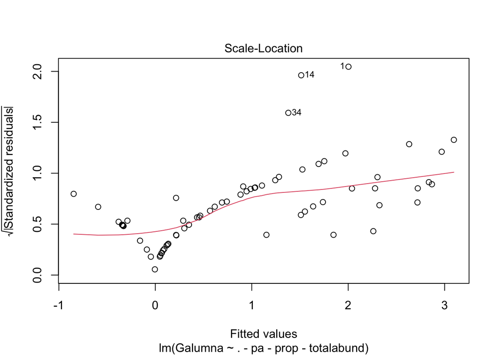

```r
plot(lm.tot.g, which = 3)
```

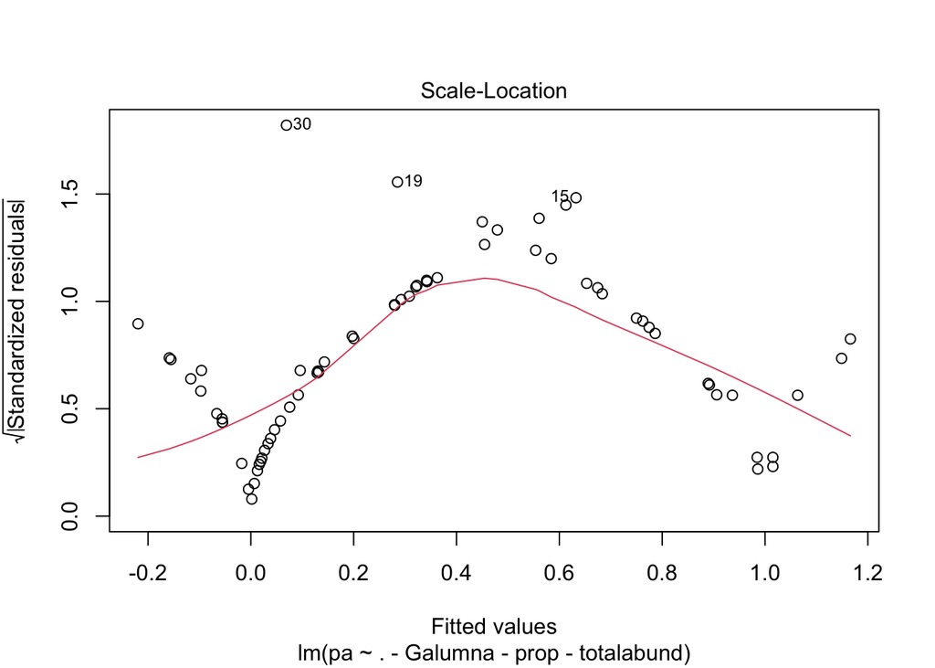

```r
plot(lm.tot.pa, which = 3)
```

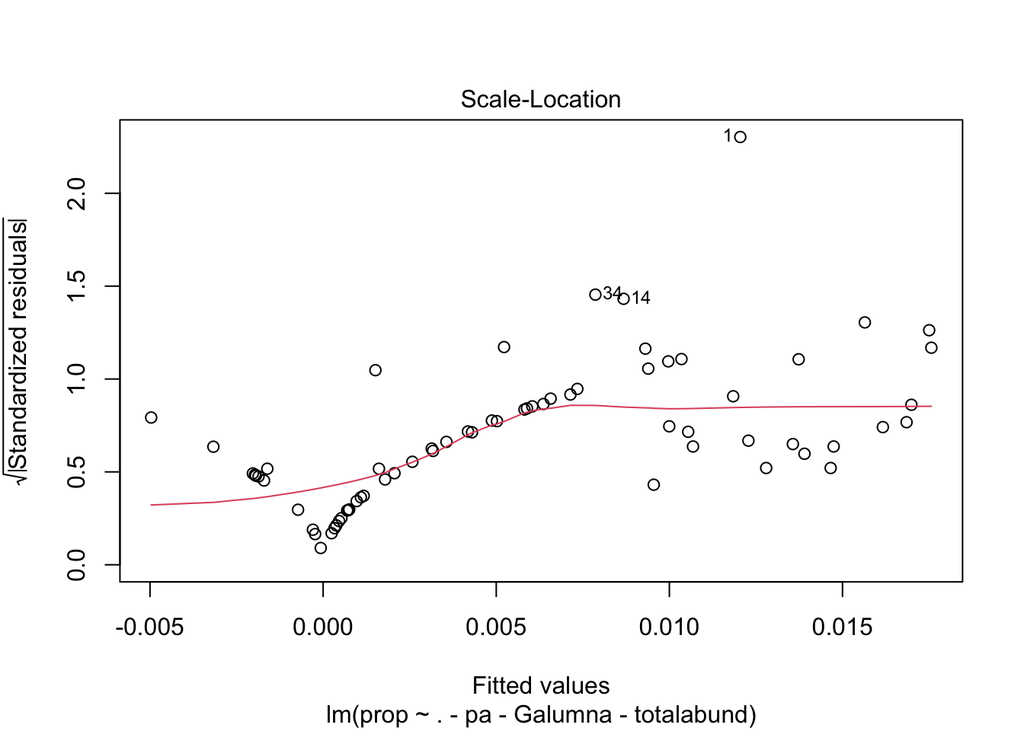

```r
plot(lm.tot.prop, which = 3)
```

Ce plot est utilisé pour checker l’homocédasticité, la ligne doit etre horizontale parce que la variance est constante

-> Test de Breush-Pagan Hyp : H0 : Le bruit est homocedastique On retrouve le modele lineaire classique (dont le bruit est homocedastique, $\sigma_i^2=\sigma^2$ pour tout $i$)

```r
bptest(lm.tot.g)
```

```
##
##  studentized Breusch-Pagan test
##
## data:  lm.tot.g
## BP = 8.2307, df = 11, p-value = 0.6925
```

```r
bptest(lm.tot.pa)
```

```
##
##  studentized Breusch-Pagan test
##
## data:  lm.tot.pa
## BP = 22.234, df = 11, p-value = 0.02262
```

```r
bptest(lm.tot.prop)
```

```
##
##  studentized Breusch-Pagan test
##
## data:  lm.tot.prop
## BP = 6.7838, df = 11, p-value = 0.8163
```

(H4) : Non autocorrélation des erreurs -> test de Durbin-Watson : H0 : Les résidus sont non correles

```r
dwtest(lm.tot.g)
```

```
##
##  Durbin-Watson test
##
## data:  lm.tot.g
## DW = 1.6263, p-value = 0.03019
## alternative hypothesis: true autocorrelation is greater than 0
```

```r
dwtest(lm.tot.pa)
```

```
##
##  Durbin-Watson test
##
## data:  lm.tot.pa
## DW = 1.9786, p-value = 0.3649
## alternative hypothesis: true autocorrelation is greater than 0
```

```r
dwtest(lm.tot.prop)
```

```
##
##  Durbin-Watson test
##
## data:  lm.tot.prop
## DW = 1.508, p-value = 0.008023
## alternative hypothesis: true autocorrelation is greater than 0
```

(H5) : Normalité des erreurs

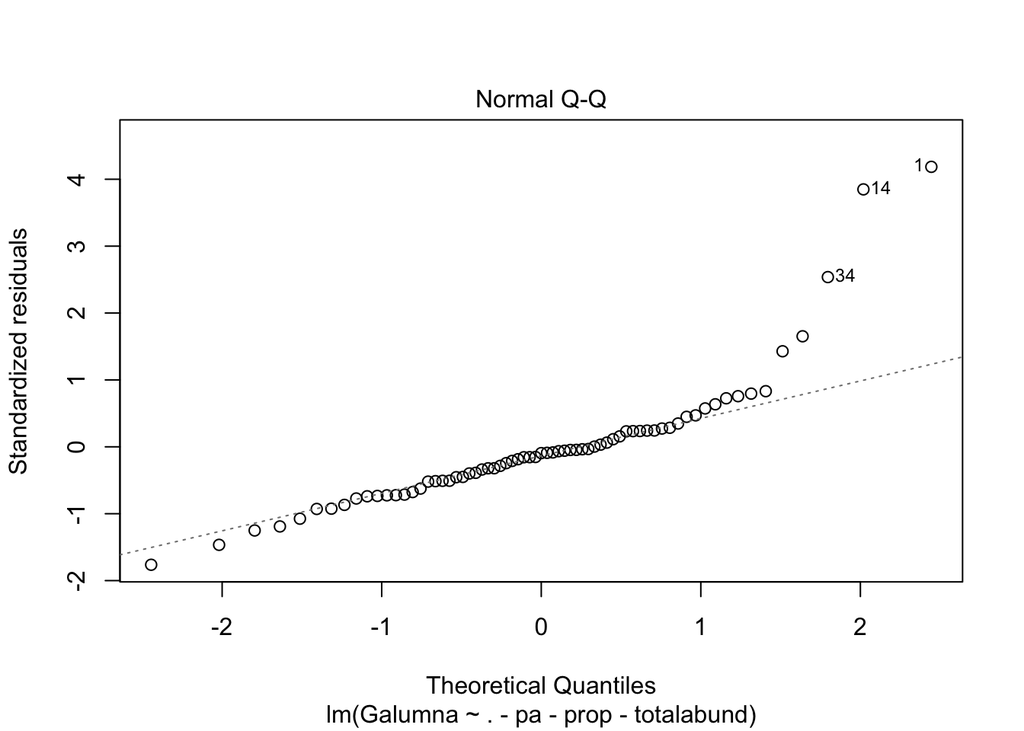

```r
plot(lm.tot.g, which = 2)
```

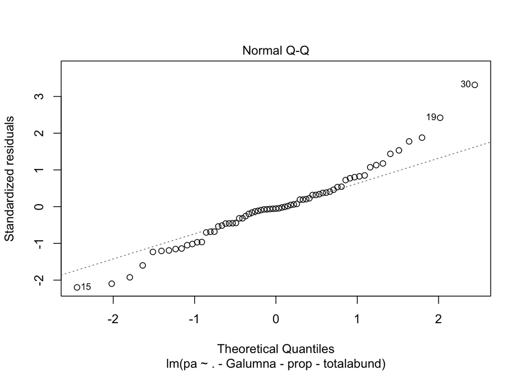

```r
plot(lm.tot.pa, which = 2)
```

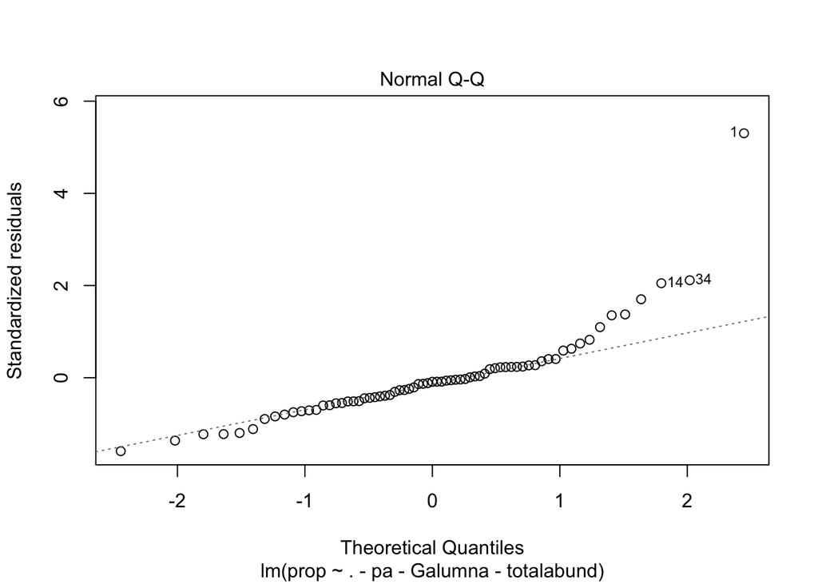

```r
plot(lm.tot.prop, which = 2)
```

- Normal Q-Q : Ce plot ets utilisé pour determiné sir les residus du model sont distribués suivant une loi normale (les points doivent suivre la ligne pour repondre à cette hypothese) (H5)

Si la rpz est (a peu pres) une droite, l’hyp de normalité est accepté

-> Test de Shapiro-Wilks : H0 : normalité

```r
shapiro.test(lm.tot.g$residuals)
```

```
##
##  Shapiro-Wilk normality test
##
## data:  lm.tot.g$residuals
## W = 0.78688, p-value = 1.088e-08
```

```r
shapiro.test(lm.tot.pa$residuals)
```

```
##
##  Shapiro-Wilk normality test
##
## data:  lm.tot.pa$residuals
## W = 0.96497, p-value = 0.04735
```

```r
shapiro.test(lm.tot.prop$residuals)
```

```
##
##  Shapiro-Wilk normality test
##
## data:  lm.tot.prop$residuals
## W = 0.78122, p-value = 7.819e-09
```

Rejete H0 pour les trois

(H7) : Non multicolinéarité des variables explicatives

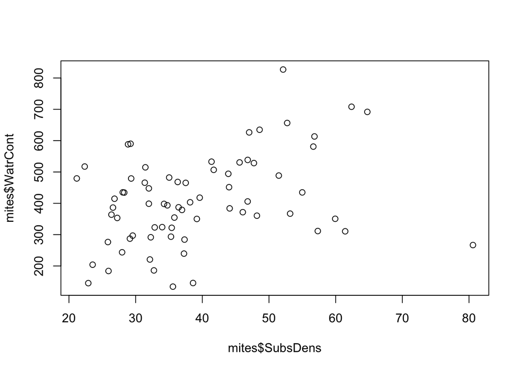

```r
plot(mites$SubsDens, mites$WatrCont)
```

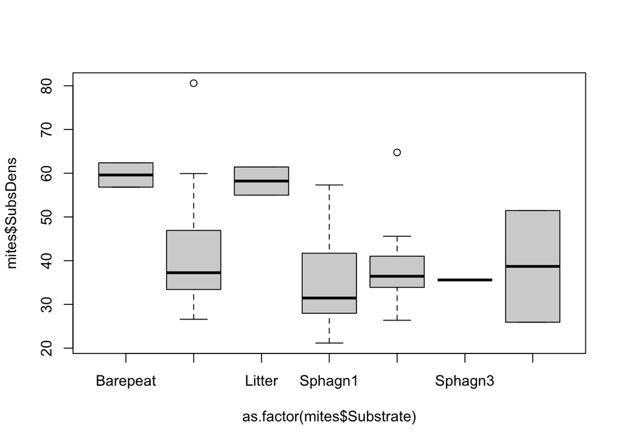

```r
boxplot(mites$SubsDens~as.factor(mites$Substrate))
```

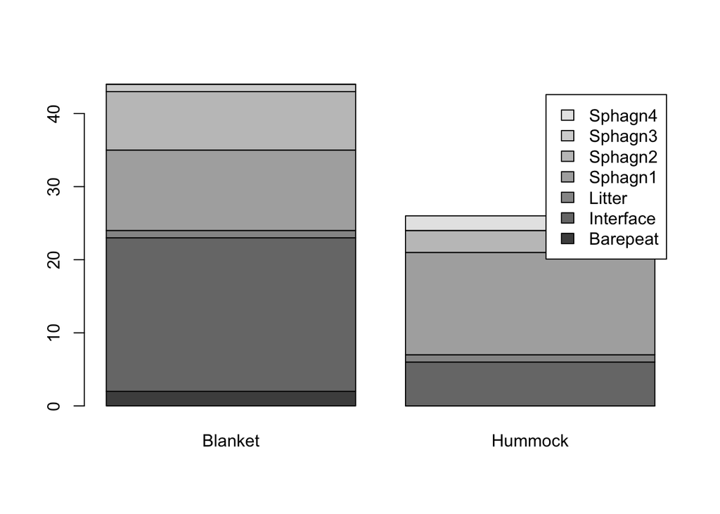

```r
barplot(table(mites$Substrate, mites$Topo), legend.text=T)
```

```r
vif(lm.tot.g)
```

```
##               GVIF Df GVIF^(1/(2*Df))
## SubsDens  1.683771  1        1.297602
## WatrCont  2.214753  1        1.488205
## Substrate 1.961711  6        1.057758
## Shrub     2.069477  2        1.199403
## Topo      1.804865  1        1.343453
```

```r
vif(lm.tot.pa)
```

```
##               GVIF Df GVIF^(1/(2*Df))
## SubsDens  1.683771  1        1.297602
## WatrCont  2.214753  1        1.488205
## Substrate 1.961711  6        1.057758
## Shrub     2.069477  2        1.199403
## Topo      1.804865  1        1.343453
```

```r
vif(lm.tot.prop)
```

```
##               GVIF Df GVIF^(1/(2*Df))
## SubsDens  1.683771  1        1.297602
## WatrCont  2.214753  1        1.488205
## Substrate 1.961711  6        1.057758
## Shrub     2.069477  2        1.199403
## Topo      1.804865  1        1.343453
```

CONCLUSION DU I) : Hypotheses du LM pas veirifées donc on ne peux pas prendre un modele linéaire

Transformation Logit :

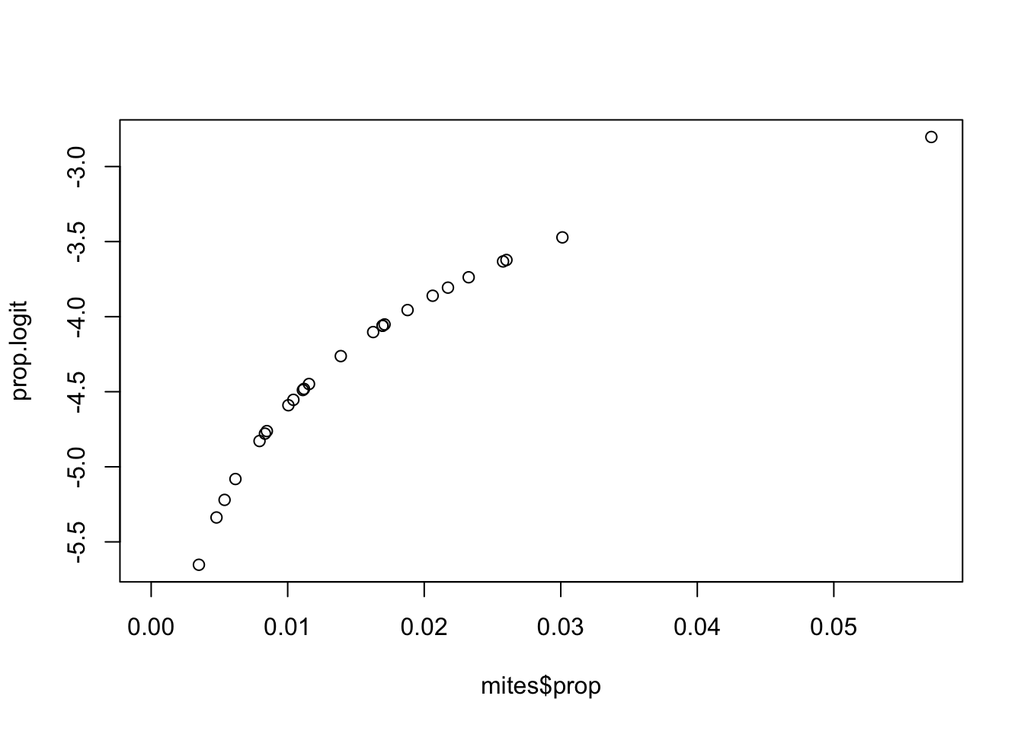

```r
logitTransform <- function(p) { log(p/(1-p)) }
prop.logit <- logitTransform(mites$prop)
plot(mites$prop, prop.logit)
```

```r
#lm.prop.logit <- lm(prop.logit~.-pa-prop-totalabund-Galumna, data =mites)
```

Probleme car Lise ne test pas ses enoncés avant de nous les donner -> demander à Juju 0 dans prop, donc probleme avec le logit car logit(0) non defini

Tranformation arcsin :

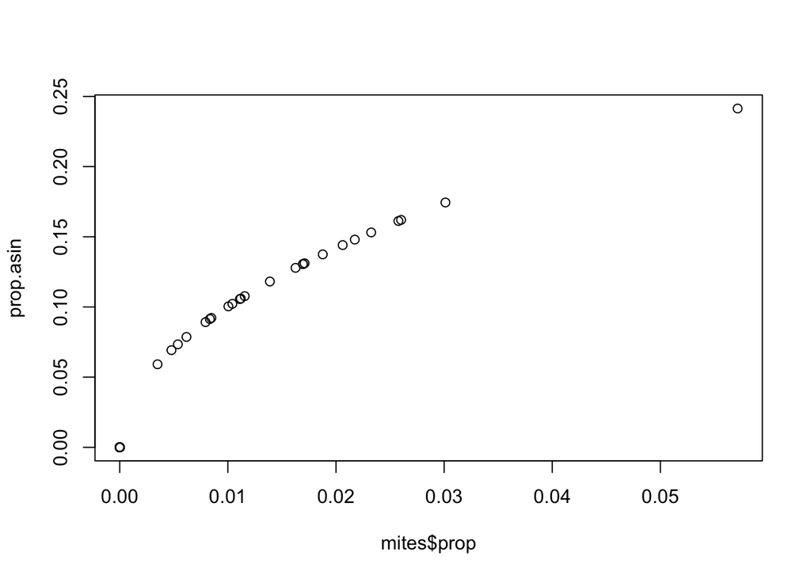

```r
asinTransform <- function(p) { asin(sqrt(p)) }
prop.asin <- asinTransform(mites$prop)
plot(mites$prop, prop.asin)
```

```r
lm.prop.asin <- lm(prop.asin~.-pa-prop-totalabund-Galumna, data =mites)
```

-> Re vérifier toutes les hypotheses comme dans le I)

(H3) : Homoscédasticité : -> Plot des résidus : “Scale-Location”

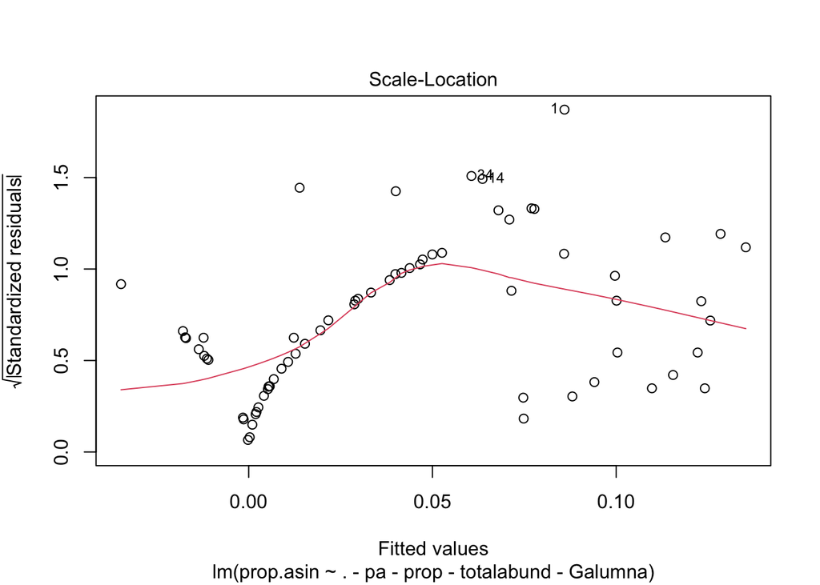

```r
plot(lm.prop.asin, which =3)
```

```r
bptest(lm.prop.asin)
```

```
##
##  studentized Breusch-Pagan test
##
## data:  lm.prop.asin
## BP = 11.542, df = 11, p-value = 0.399
```

Pas tres concluant pour amélirorer les problemes de variance, car deja bien avant la transformation.

```r
boxcox
```

```
## function (object, ...)
## UseMethod("boxcox")
## <bytecode: 0x7fc35ac4f328>
## <environment: namespace:MASS>
```

## 2. GLM Régression logistique binaire sur la variable réponse Occurrence (pa) :

Objectif : déterminer le meilleur modèle, interpréter les coefficients, puis évaluer l’ajustement de ce modèle et son pouvoir prédictif.

— Recherche du meilleur modèle —

- Méthode ‘à la main’

Pour débuter, on construit le modèle général (avec toutes les variables explicatives) pour déterminer lesquelles sont significatives:

```r
glm.tot.pa <- glm(pa~WatrCont + SubsDens + Topo + Shrub + Substrate, data=mites, family = "binomial")
summary(glm.tot.pa)
```

```
##
## Call:
## glm(formula = pa ~ WatrCont + SubsDens + Topo + Shrub + Substrate,
##     family = "binomial", data = mites)
##
## Deviance Residuals:
##      Min        1Q    Median        3Q       Max
## -1.96119  -0.20137  -0.00004   0.11385   2.26516
##
## Coefficients:
##                      Estimate Std. Error z value Pr(>|z|)
## (Intercept)        -1.430e+01  1.022e+04  -0.001   0.9989
## WatrCont           -2.162e-02  8.505e-03  -2.542   0.0110 *
## SubsDens            1.625e-01  7.690e-02   2.114   0.0345 *
## TopoHummock         2.135e+00  1.046e+00   2.040   0.0413 *
## ShrubMany           3.918e-01  1.057e+00   0.371   0.7109
## ShrubNone          -1.585e+01  3.627e+03  -0.004   0.9965
## SubstrateInterface  1.351e+01  1.022e+04   0.001   0.9989
## SubstrateLitter     3.251e+01  1.563e+04   0.002   0.9983
## SubstrateSphagn1    1.523e+01  1.022e+04   0.001   0.9988
## SubstrateSphagn2    1.393e+01  1.022e+04   0.001   0.9989
## SubstrateSphagn3    3.158e+01  2.047e+04   0.002   0.9988
## SubstrateSphagn4    3.387e+01  1.577e+04   0.002   0.9983
## ---
## Signif. codes:  0 '***' 0.001 '**' 0.01 '*' 0.05 '.' 0.1 ' ' 1
##
## (Dispersion parameter for binomial family taken to be 1)
##
##     Null deviance: 91.246  on 69  degrees of freedom
## Residual deviance: 29.897  on 58  degrees of freedom
## AIC: 53.897
##
## Number of Fisher Scoring iterations: 19
```

Daprès cette sortie, les variables significatives semblent être WatrCont, SubsDens et Topo.

On peut alors tester un modèle uniquement avec celles-ci :

```r
glm.best.pa <- glm(pa~WatrCont + SubsDens + Topo, data=mites, family = "binomial")
summary(glm.best.pa)
```

```
##
## Call:
## glm(formula = pa ~ WatrCont + SubsDens + Topo, family = "binomial",
##     data = mites)
##
## Deviance Residuals:
##     Min       1Q   Median       3Q      Max
## -2.1471  -0.2356  -0.1091   0.3515   2.3526
##
## Coefficients:
##              Estimate Std. Error z value Pr(>|z|)
## (Intercept) -0.582892   2.223158  -0.262 0.793174
## WatrCont    -0.021623   0.006252  -3.459 0.000543 ***
## SubsDens     0.172951   0.064303   2.690 0.007153 **
## TopoHummock  2.737763   0.940022   2.912 0.003586 **
## ---
## Signif. codes:  0 '***' 0.001 '**' 0.01 '*' 0.05 '.' 0.1 ' ' 1
##
## (Dispersion parameter for binomial family taken to be 1)
##
##     Null deviance: 91.246  on 69  degrees of freedom
## Residual deviance: 34.475  on 66  degrees of freedom
## AIC: 42.475
##
## Number of Fisher Scoring iterations: 7
```

Ce modèle semble mieux car les variables sont toutes vraiment significatives.

Afin de s’assurer de la significativité des paramètres, nous pouvons réaliser un test de déviance :

```r
anova(glm.tot.pa, test = 'Chisq')
```

|  | Df | Deviance | Resid. Df | Resid. Dev | Pr(>Chi) |
| --- | --- | --- | --- | --- | --- |
| NULL | NA | NA | 69 | 91.24592 | NA |
| WatrCont | 1 | 33.3709264 | 68 | 57.87499 | 7.615395e-09 |
| SubsDens | 1 | 12.8781150 | 67 | 44.99688 | 3.324469e-04 |
| Topo | 1 | 10.5216536 | 66 | 34.47522 | 1.179839e-03 |
| Shrub | 2 | 0.3815983 | 64 | 34.09363 | 8.262985e-01 |
| Substrate | 6 | 4.1964552 | 58 | 29.89717 | 6.501099e-01 |

Les mêmes variables qu’auparavnt ressortent comme significatives. Cela confirme notre choix de garder les variables WatrCont, SubsDens et Topo dans notre modèle.

Nous pouvons comparer ce modèle obtenu avec celui déterminé par une sélection automatique.

- Méthode de sélection stepwise descendante avec le critère AIC

```r
glm.tot.pa.step <- step(glm.tot.pa, direction = "backward")
```

```
## Start:  AIC=53.9
## pa ~ WatrCont + SubsDens + Topo + Shrub + Substrate
```

```
##             Df Deviance    AIC
## - Substrate  6   34.094 46.094
## - Shrub      2   30.475 50.475
## <none>           29.897 53.897
## - Topo       1   34.737 56.737
## - SubsDens   1   37.914 59.914
## - WatrCont   1   44.114 66.114
##
## Step:  AIC=46.09
## pa ~ WatrCont + SubsDens + Topo + Shrub
##
##            Df Deviance    AIC
## - Shrub     2   34.475 42.475
## <none>          34.094 46.094
## - Topo      1   43.409 53.409
## - SubsDens  1   45.956 55.956
## - WatrCont  1   55.091 65.091
##
## Step:  AIC=42.48
## pa ~ WatrCont + SubsDens + Topo
##
##            Df Deviance    AIC
## <none>          34.475 42.475
## - Topo      1   44.997 50.997
## - SubsDens  1   48.762 54.762
## - WatrCont  1   64.632 70.632
```

```r
glm.tot.pa.step$formula
```

```
## pa ~ WatrCont + SubsDens + Topo
```

La sélection automatique de modèle retient également le modèle contenant les variables WatrCont, SubsDens et Topo car c’est celui pour lequel l’AIC est le plus faible.

Par conséquent, nous retenons ce modèle pour la suite.

— Interprétation des coefficients —

La sortie de notre modèle indique que le contenu en eau, la densité du substrat et la topographie sont associés significativement à l’occurrence de mites. Cependant, on peut également interpréter les coefficients de la pente grâce aux odds-ratio.

```r
exp(glm.best.pa$coefficients)
```

```
## (Intercept)    WatrCont    SubsDens TopoHummock
##   0.5582817   0.9786086   1.1888083  15.4523718
```

Ici, les coefficients de WatrCont et SubsDens étant proches de 1, on en déduit que l’augmentation d’une unité du contenu en eau ou de la densité du substrat n’a pas vraiment d’impact sur la présence de mites. Cependant, le coefficient associé à la topologie est très nettement supérieur à 1. Cela qui signifique que lorsque la topographie est de type Hummock, alors il y a un fort risque de présence de mites.

— Evaluation de l’ajustement du modèle —

Pour tester la qualité de l’ajustement de notre modèle, on peut utiliser le test de Pearson basé sur les résidus de Pearson.

```r
res <- sum(residuals(glm.best.pa, type = "pearson")^2)
ddl <- df.residual(glm.best.pa)
pvalue = 1 - pchisq(res,ddl)
pvalue
```

```
## [1] 0.9835327
```

La p-value était très grande, on admet que le modèle est très bien adapté aux données.

On peut également effectuer un test d’Hosmer-Lemeshow pour évaluer la pertinence du modèle :

```r
hoslem.test(mites$pa, fitted(glm.best.pa))
```

```
##
##  Hosmer and Lemeshow goodness of fit (GOF) test
##
## data:  mites$pa, fitted(glm.best.pa)
## X-squared = 2.678, df = 8, p-value = 0.9529
```

De même, la très grande p-value nous indique que le modèle est bien adapté aux données.

Avant de valider définitivement le choix de ce modèle, il faut évaluer son pouvoir prédictif.

— Evaluation de son pouvoir prédictif —

Pour évaluer le pouvoir prédictif de notre modèle, nous allons juger les prédictions de notre modèle grâce à une courbe ROC. Afin de ne pas prédire sur des individus ayant servis à la construction de modèle, nous effectuons une validation croisée. En effet, pour chaque individu i, nous estimons le modèle sans cet individu puis nous prédisons la valeur de pa pour celui-ci. Nous obtenons alors les prédictions de pa pour tous les individus et nous pouvons tracer la courbe ROC.

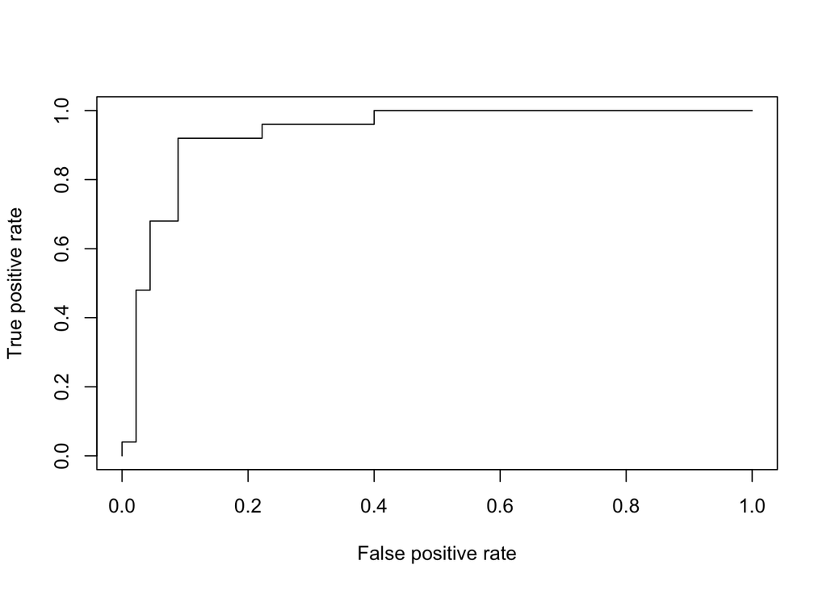

```r
n <- nrow(mites)
pred=1:n
for (i in 1:n){
  # On estime le modèle sans i (on l'enlève lorsqu'on estime le modèle)
  fit=glm(pa~WatrCont + SubsDens + Topo, data=mites, family="binomial", subset=-i)
  # On prédit la proba asscoiée à i
  pred[i]=predict(fit,mites[i,-2], type="response")
}

pr=prediction(pred,mites$pa)
roc=performance(pr, measure="tpr",x.measure="fpr")
plot(roc)
```

Cette courbe résume le taux de vrais positifs en fonction du taux de faux positifs. Elle est d’autant meilleure qu’elle s’éloigne de la diagonale. Ici, nous avons une courbe largement au dessus de la diagonale. Nous pouvons d’ailleurs calculer son aire sous la courbe (AUC) :

```r
perf <- performance(pr, "auc")
perf@y.values[[1]]
```

```
## [1] 0.9351111
```

L’aire sous la courbe est proche de 1 : le pouvoir prédictif de notre modèle est alors très bon.

Enfin, nous pouvons résumer les bonnes et mauvaises prédictions de notre modèle grâce à une matrice de confusion. Pour cela, il est intéressant de déterminer en amont le seuil à partir duquel on admet la présence de mites. On trace alors la courbe du taux d’erreur en fonction des différents seuils.

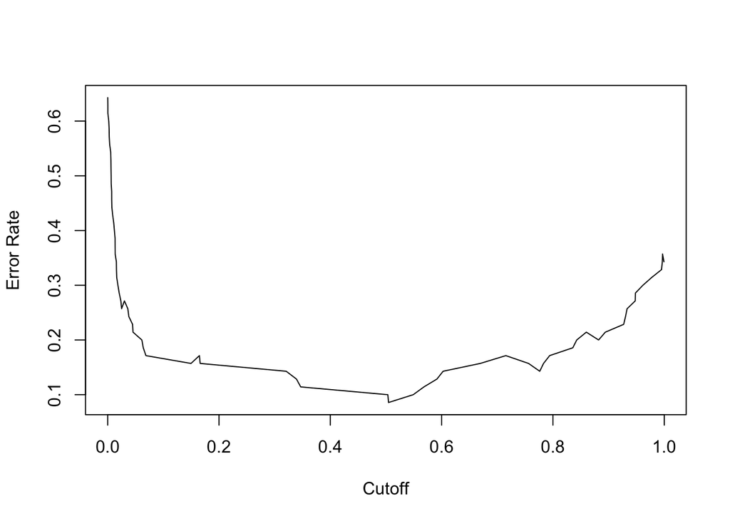

```r
res.err=performance(pr,measure = "err")
plot(res.err)
```

Nous remarquons que le taux d’erreur le plus faible est pour un seuil de 0.5. C’est alors le seuil que nous allons choisir pour étblir notre matrice de confusion.

```r
table(pred>0.5, mites$pa)
```

```
##
##          0  1
##   FALSE 40  2
##   TRUE   5 23
```

Ainsi, nous en déduisons que le modèle expliquant l’occurrence de mites grâce au contenu en eau, à la densité du substrat et à la topographie obtient des bons résultats, tant sur son ajustement que sur son pouvoir prédictif.

## 3. GLM Régression Logistique sur les données agrégées

Objectif : expliquer la fréquence relative `prop`, déterminer le meilleur modèle pour cette variable réponse, interpréter les coefficients, puis évaluer l’ajustement de ce modèle et son pouvoir prédictif.

### Recherche du meilleur modèle

La variable `prop` est, comme son nom l’indique, une variable en proportion. Malgré qu’il ne s’agisse pas d’une variable binaire, ce cas est proche d’une régression logistique. Sous R, on peut utiliser la fonction `glm` de manière semblable à lorsque l’on fait une régression logistique classique, mais en précisant cette fois des poids a priori.

On suivra la même méthode que dans la partie précédente pour chercher le meilleur modèle : une recherche à la main dans un premier temps, puis une méthode de sélection automatique.

**Recherche à la main :**

```r
prop.reg.tot <- glm(prop~WatrCont + SubsDens + Topo + Shrub + Substrate, data=mites, family = "binomial", weights = totalabund)
```

```
## Warning: glm.fit: fitted probabilities numerically 0 or 1 occurred
```

```r
summary(prop.reg.tot)
```

```
##
## Call:
## glm(formula = prop ~ WatrCont + SubsDens + Topo + Shrub + Substrate,
##     family = "binomial", data = mites, weights = totalabund)
##
## Deviance Residuals:
##     Min       1Q   Median       3Q      Max
## -1.4587  -0.9228  -0.1041   0.0000   4.1062
##
## Coefficients:
##                      Estimate Std. Error z value Pr(>|z|)
## (Intercept)        -2.028e+01  6.816e+03  -0.003 0.997626
## WatrCont           -5.215e-03  1.508e-03  -3.458 0.000544 ***
## SubsDens            1.962e-02  1.133e-02   1.732 0.083321 .
## TopoHummock         4.437e-01  3.585e-01   1.238 0.215847
## ShrubMany           2.483e-01  3.029e-01   0.820 0.412226
## ShrubNone          -1.780e+01  2.340e+03  -0.008 0.993931
## SubstrateInterface  1.598e+01  6.816e+03   0.002 0.998129
## SubstrateLitter     1.646e+01  6.816e+03   0.002 0.998073
## SubstrateSphagn1    1.616e+01  6.816e+03   0.002 0.998108
## SubstrateSphagn2    1.488e+01  6.816e+03   0.002 0.998258
## SubstrateSphagn3    1.577e+01  6.816e+03   0.002 0.998154
## SubstrateSphagn4    1.627e+01  6.816e+03   0.002 0.998095
## ---
## Signif. codes:  0 '***' 0.001 '**' 0.01 '*' 0.05 '.' 0.1 ' ' 1
##
## (Dispersion parameter for binomial family taken to be 1)
##
##     Null deviance: 140.70  on 69  degrees of freedom
## Residual deviance:  67.73  on 58  degrees of freedom
## AIC: 158.48
##
## Number of Fisher Scoring iterations: 19
```

Lorsque l’on effectue le modèle complet, on obtient un warning qui nous dit qu’une ou plusieurs observations du jeu de données sont prédites à 0 ou 1, ce qui ne veut pas forcément dire que la régression logistique est mauvaise. On décide donc d’ignorer le warning. Cependant, on voit qu’il n’y que très peu de variables significatives. On créé un modèle avec les deux variables les plus significatives du modèle complet : `WatrCont` et `SubsDens`.

```r
prop.reg.2 <- glm(prop~WatrCont + SubsDens, data=mites, family = "binomial", weights = totalabund)
summary(prop.reg.2)
```

```
##
## Call:
## glm(formula = prop ~ WatrCont + SubsDens, family = "binomial",
##     data = mites, weights = totalabund)
##
## Deviance Residuals:
##     Min       1Q   Median       3Q      Max
## -1.6469  -1.0054  -0.6332  -0.1536   4.6133
##
## Coefficients:
##              Estimate Std. Error z value Pr(>|z|)
## (Intercept) -3.400771   0.430215  -7.905 2.68e-15 ***
## WatrCont    -0.007220   0.001099  -6.568 5.10e-11 ***
## SubsDens     0.022387   0.009185   2.437   0.0148 *
## ---
## Signif. codes:  0 '***' 0.001 '**' 0.01 '*' 0.05 '.' 0.1 ' ' 1
##
## (Dispersion parameter for binomial family taken to be 1)
##
##     Null deviance: 140.702  on 69  degrees of freedom
## Residual deviance:  85.387  on 67  degrees of freedom
## AIC: 158.14
##
## Number of Fisher Scoring iterations: 5
```

Cette fois-ci on voit que toutes les variables, ainsi que la constante sont significatives pour le test de Wald. L’AIC est très proche de celui du modèle complet : environ 158.

**Recherche automatique :**

On effectue maintenant une recherche automatique du meilleur modèle en partant du plus gros modèle et en se basant sur le critère BIC, critère explicatif.

```r
prop.reg.back<-step(prop.reg.tot, direction="backward", k=log(nrow(mites)))
```

```
## Start:  AIC=185.47
## prop ~ WatrCont + SubsDens + Topo + Shrub + Substrate
```

```
##             Df Deviance    AIC
## - Substrate  6   71.130 163.38
## - Topo       1   69.294 182.78
## - Shrub      2   74.592 183.83
## - SubsDens   1   70.483 183.97
## <none>           67.730 185.47
## - WatrCont   1   81.674 195.16
##
## Step:  AIC=163.38
## prop ~ WatrCont + SubsDens + Topo + Shrub
##
##            Df Deviance    AIC
## - Shrub     2   78.181 161.93
## <none>          71.130 163.38
## - SubsDens  1   75.561 163.56
## - Topo      1   75.743 163.74
## - WatrCont  1   88.913 176.91
##
## Step:  AIC=161.93
## prop ~ WatrCont + SubsDens + Topo
##
##            Df Deviance    AIC
## <none>          78.181 161.93
## - Topo      1   85.387 164.89
## - SubsDens  1   85.905 165.40
## - WatrCont  1  118.911 198.41
```

```r
prop.reg.back$formula
```

```
## prop ~ WatrCont + SubsDens + Topo
```

Avec une procédure de sélection backward, on garde 3 variables : `WatrCont`, `SubsDens` et `Topo`.

On va maintenant comparer ces trois modèles avec le BIC :

```r
BIC(prop.reg.tot)
```

```
## [1] 185.4658
```

```r
BIC(prop.reg.2)
```

```
## [1] 164.8866
```

```r
BIC(prop.reg.back)
```

```
## [1] 161.9289
```

Le modèle à trois variables est celui qui minimise le BIC. On peut tout de même effectuer un test de modèle emboîtés afin de regarder si la troisième variable `Topo` est bien significative. On teste donc le modèle à 2 variables contre celui à 3 variables.

```r
anova(prop.reg.2, prop.reg.back,test="Chisq")
```

|  | Resid. Df | Resid. Dev | Df | Deviance | Pr(>Chi) |
| --- | --- | --- | --- | --- | --- |
| 1 | 67 | 85.38712 | NA | NA | NA |
| 2 | 66 | 78.18086 | 1 | 7.206255 | 0.007264994 |

La p-value est inférieure à 0.05 donc la variable `Topo` est significative.

et voici son summary :

```r
summary(prop.reg.back)
```

```
##
## Call:
## glm(formula = prop ~ WatrCont + SubsDens + Topo, family = "binomial",
##     data = mites, weights = totalabund)
##
## Deviance Residuals:
##     Min       1Q   Median       3Q      Max
## -1.7781  -0.8947  -0.5749  -0.1380   4.1291
##
## Coefficients:
##              Estimate Std. Error z value Pr(>|z|)
## (Intercept) -4.229742   0.542002  -7.804 6.00e-15 ***
## WatrCont    -0.006823   0.001157  -5.896 3.73e-09 ***
## SubsDens     0.029161   0.009880   2.951  0.00316 **
## TopoHummock  0.728616   0.280072   2.602  0.00928 **
## ---
## Signif. codes:  0 '***' 0.001 '**' 0.01 '*' 0.05 '.' 0.1 ' ' 1
##
## (Dispersion parameter for binomial family taken to be 1)
##
##     Null deviance: 140.702  on 69  degrees of freedom
## Residual deviance:  78.181  on 66  degrees of freedom
## AIC: 152.93
##
## Number of Fisher Scoring iterations: 5
```

On remarque que toutes les variables sont significatives d’après le test de Wald.

### Interprétation des coefficients

On peut interpréter les coefficients du modèle pour nos trois variables grâce à leurs odds-ratios. L’odd-ratio pour la variable $j$ est égal à $\exp(\beta_j)$.

```r
round(exp(prop.reg.back$coefficients),2)
```

```
## (Intercept)    WatrCont    SubsDens TopoHummock
##        0.01        0.99        1.03        2.07
```

L’odd-ratio pour la variable `WatrCont` est inférieur à 1. De plus, sa p-value associée au test de Wald est inférieure à 5% donc on peut dire que la proportion de mites est significativement moins élevée si la quantité d’eau dans le sol augmente. L’odd-ratio de `SubsDens` est quant à lui supérieur à 1, et sa p-value pour le test de Wald inférieure à 5%. Cela signifie que la proportion de mites sera significativement plus importante si la densité du substrat augmente.  
Enfin, l’odd-ratio pour `Topo` vaut 2.07 et sa p-value est inférieure à 5%. Donc on peut conclure que si la topographie est de type Hummock, la proportion de mites sera significativement plus élevée.

### Diagnostics

**Effet levier :**

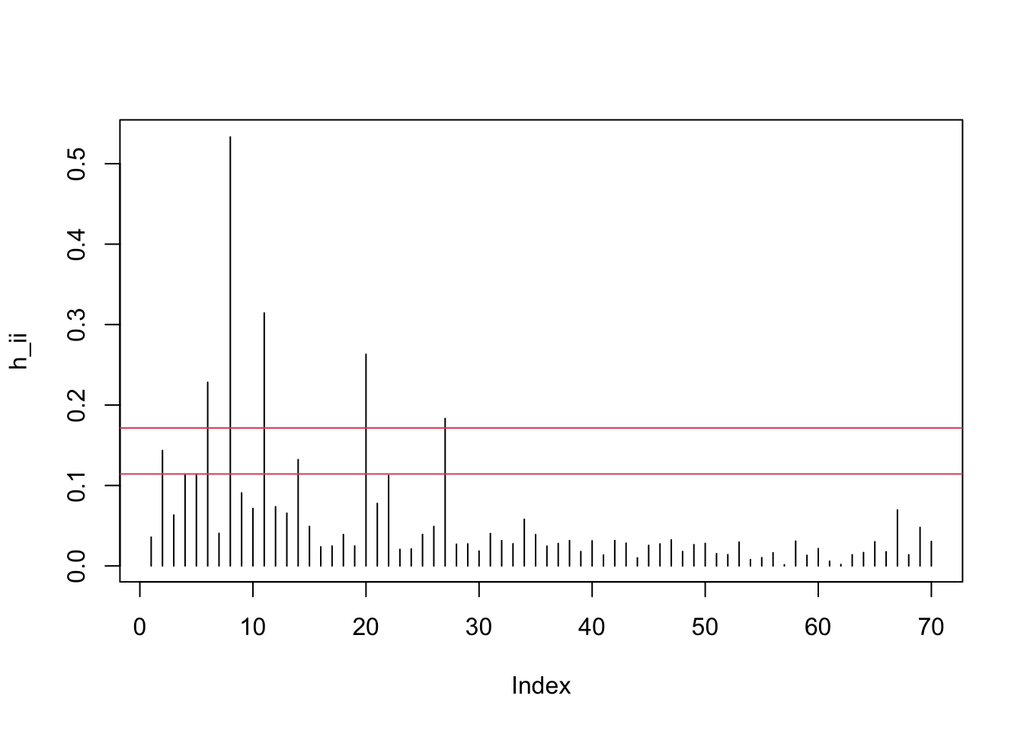

```r
p<-length(prop.reg.back$coefficients)
n<-nrow(mites)
plot(influence(prop.reg.back)$hat, type="h", ylab="h_ii")
abline(h=c(2*p/n, 3*p/n), col=2)
```

On observe que 5 observations peuvent être déclarées comme “points leviers”, c’est-à-dire qu’ils déterminent fortement leur propre estimation.

**Points influents :**

Les points influents sont des points qui influent sur le modèle de telle sorte que si on les enlèves, l’estimation des coefficients sera fortement changée. Pour les observer, on représente leur distance de Cook.

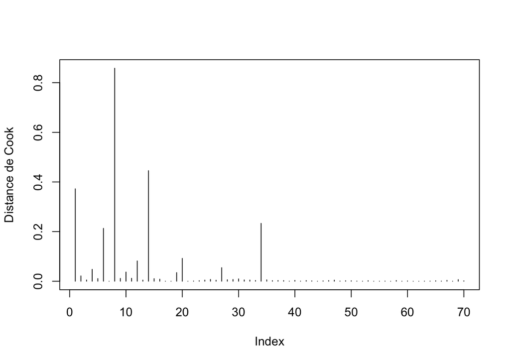

```r
plot(cooks.distance(prop.reg.back), type="h", ylab="Distance de Cook")
```

On relève plusieurs points influents. Notamment la 8ème observation, qui était déjà un point levier.

**Analyse des résidus :**

Enfin, nous allons analyser les résidus. On effectue pour cela un test de Pearson. L’hypothèse nulle de ce test est : $H_0 :=$ le modèle ajuste correctement les données.

```r
res <- sum(residuals(prop.reg.back, type = "pearson")^2)
ddl <- n-(p+1)
pvalue <- 1 - pchisq(res,ddl)
pchisq(res,ddl)
```

```
## [1] 0.9963283
```

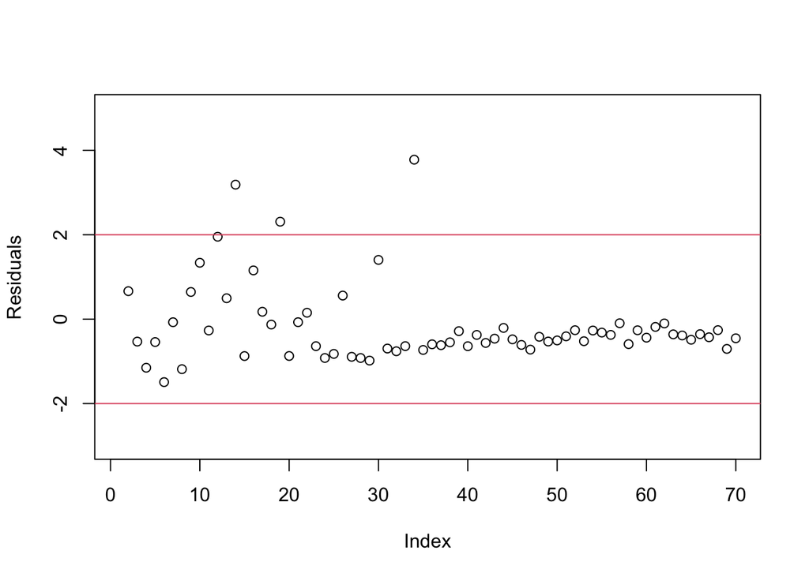

```r
res<-residuals(prop.reg.back, type="pearson", )
plot(res, ylim=c(-3,5), ylab="Residuals")
abline(h=c(-2,2), col=2)
```

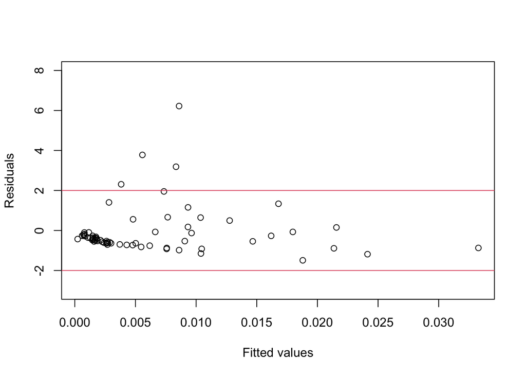

```r
plot(predict(prop.reg.back, type="r"), res, xlab="Fitted values", ylab="Residuals", ylim=c(-3,8))
abline(h=c(-2,2), col=2)
```

## 4) GLM Régression Poisson sur Abondance (Galumna) :

Objectif : Modéliser l’abondance de l’espèce Galumna en fonction des caractéristiques du substrat (son contenu en eau ‘WartCont’ et sa densité ‘SubsDens’) et si nécessaire des autres variables environmentales.

Rappelons que le modèle linéaire général est un cas particulier de GLM, on a : $Y = X\beta + e$ avec $e = (\epsilon_1, \dots, \epsilon_n)^T$ et $\epsilon_i$ sont i.i.d suivant $N(0,\theta^2)$.

Pour une distribution Poisson $y~Pois(\lambda)$ avec le lien log par défault nous avons $log(\lambda)=\eta$ avec l’inverse de ce lien $\lambda=e^\eta$.

Comme pour la régression logistique, la régression de Poisson utilise la fonction glm. Il faut spécifier la famille poisson et (optionnellement) le lien log. En effet, le logarithme est la foncton de lien par défaut pour la régression de Poisson sur `R`.

```r
glm.poi <- glm(Galumna~WatrCont + SubsDens, family = poisson(link = "log"), data = mites )
summary(glm.poi)
```

```
##
## Call:
## glm(formula = Galumna ~ WatrCont + SubsDens, family = poisson(link = "log"),
##     data = mites)
##
## Deviance Residuals:
##     Min       1Q   Median       3Q      Max
## -2.0851  -0.9488  -0.6573  -0.1344   4.5579
##
## Coefficients:
##              Estimate Std. Error z value Pr(>|z|)
## (Intercept)  1.885689   0.425194   4.435 9.21e-06 ***
## WatrCont    -0.008304   0.001118  -7.426 1.12e-13 ***
## SubsDens     0.023367   0.008380   2.788   0.0053 **
## ---
## Signif. codes:  0 '***' 0.001 '**' 0.01 '*' 0.05 '.' 0.1 ' ' 1
##
## (Dispersion parameter for poisson family taken to be 1)
##
##     Null deviance: 168.25  on 69  degrees of freedom
## Residual deviance: 101.49  on 67  degrees of freedom
## AIC: 174.65
##
## Number of Fisher Scoring iterations: 6
```

Essayons un modèle plus complexe avec interaction entre son contenu en eau et sa densité.

```r
glm.poi1 <- glm(Galumna~WatrCont * SubsDens , family = poisson(link = "log"), data = mites )
summary(glm.poi1)
```

```
##
## Call:
## glm(formula = Galumna ~ WatrCont * SubsDens, family = poisson(link = "log"),
##     data = mites)
##
## Deviance Residuals:
##     Min       1Q   Median       3Q      Max
## -1.8216  -0.9343  -0.7041  -0.1646   4.6781
##
## Coefficients:
##                     Estimate Std. Error z value Pr(>|z|)
## (Intercept)        3.428e+00  1.051e+00   3.262 0.001105 **
## WatrCont          -1.402e-02  3.798e-03  -3.692 0.000223 ***
## SubsDens          -1.663e-02  2.587e-02  -0.643 0.520274
## WatrCont:SubsDens  1.421e-04  8.667e-05   1.639 0.101148
## ---
## Signif. codes:  0 '***' 0.001 '**' 0.01 '*' 0.05 '.' 0.1 ' ' 1
##
## (Dispersion parameter for poisson family taken to be 1)
##
##     Null deviance: 168.254  on 69  degrees of freedom
## Residual deviance:  99.151  on 66  degrees of freedom
## AIC: 174.31
##
## Number of Fisher Scoring iterations: 6
```

L’AIC de ce modele est égale à 174.31, ce qui est sensiblement égale au premier modèle qui avait un AIC de 174.65. Cependant, on observe dans le `summary` que la varible `SubsDens` ainsi que la variable interaction `WatrCont:SubsDens` ne sont pas significatives. Ce modele n’a donc pas un meilleur ajustement, nous le rejeton.

Le modele selectionné s’écrit donc :
$$ln(\lambda)=\beta_O+\beta_1*WatrCont+\beta_2*SubsDens$$
ce qui nous donne à l’aide du `summary` de notre modèle :
$$ln(\lambda)=1.89-0.008*WatrCont+0.023*SubsDens$$
Nous allons maintenant interpreter les coefficients de notre modèle. Nous allons determiner l’effet de chaque coefficient du modèle sur le prédicteur linéaire $\mu_i=\beta_O+\beta_1*WatrCont+\beta_2*SubsDens$, puis de déduire l’effet sur la moyenne de réponse à partir de la fonction $\lambda=e^\eta$.

Pour determiner si le $\chi^2$ diffère significativement de la valeur attendue selon la distribution de Poisson, nous pouvons calculer la probabilité d’avoir obtenu un $\chi^2$ plus élevé si le modèle est correct.

```r
chisq <- sum((mites$Galumna-fitted(glm.poi))^2/fitted(glm.poi))
1-pchisq(chisq, df=glm.poi$df.residual)
```

```
## [1] 3.63154e-07
```

```r
disp <- chisq/glm.poi$df.residual
disp
```

```
## [1] 2.100732
```

L’estimé du paramètre de dispersion est de $\hat{c}=2.1$. Cependant, l’estimation de ce paramètre de dispersion n’est pas trop élevé. Les estimés des coefficients de la régression de Poisson demeurent valides, mais il faut multiplier leurs erreurs-types par $\sqrt{\hat{c}}$. Autrement dit, la surdispersion n’introduit pas de biais, mais augmente l’incertitude sur les valeurs des coefficients.

Pour corriger les erreurs-types, nous allons ajouter un argument `disperson` dans la fonction `summary`. Ce qui revient à utiliser la famille `quasipoisson` dans notre modèle.

```r
summary(glm.poi, dispersion = disp)
```

```
##
## Call:
## glm(formula = Galumna ~ WatrCont + SubsDens, family = poisson(link = "log"),
##     data = mites)
##
## Deviance Residuals:
##     Min       1Q   Median       3Q      Max
## -2.0851  -0.9488  -0.6573  -0.1344   4.5579
##
## Coefficients:
##              Estimate Std. Error z value Pr(>|z|)
## (Intercept)  1.885689   0.616272   3.060  0.00221 **
## WatrCont    -0.008304   0.001621  -5.124 2.99e-07 ***
## SubsDens     0.023367   0.012146   1.924  0.05439 .
## ---
## Signif. codes:  0 '***' 0.001 '**' 0.01 '*' 0.05 '.' 0.1 ' ' 1
##
## (Dispersion parameter for poisson family taken to be 2.100732)
##
##     Null deviance: 168.25  on 69  degrees of freedom
## Residual deviance: 101.49  on 67  degrees of freedom
## AIC: 174.65
##
## Number of Fisher Scoring iterations: 6
```

```r
glm.poi2 <- glm(Galumna~WatrCont+SubsDens , family = quasipoisson, data = mites )
summary(glm.poi2)
```

```
##
## Call:
## glm(formula = Galumna ~ WatrCont + SubsDens, family = quasipoisson,
##     data = mites)
##
## Deviance Residuals:
##     Min       1Q   Median       3Q      Max
## -2.0851  -0.9488  -0.6573  -0.1344   4.5579
##
## Coefficients:
##              Estimate Std. Error t value Pr(>|t|)
## (Intercept)  1.885689   0.616272   3.060  0.00318 **
## WatrCont    -0.008304   0.001621  -5.124 2.74e-06 ***
## SubsDens     0.023367   0.012146   1.924  0.05864 .
## ---
## Signif. codes:  0 '***' 0.001 '**' 0.01 '*' 0.05 '.' 0.1 ' ' 1
##
## (Dispersion parameter for quasipoisson family taken to be 2.100733)
##
##     Null deviance: 168.25  on 69  degrees of freedom
## Residual deviance: 101.49  on 67  degrees of freedom
## AIC: NA
##
## Number of Fisher Scoring iterations: 6
```